# Predicting Exercise Type with Random Tress

Arthur Luna - arthurlunabcf@outlook.com

## Downloading and selecting data

The first step is to download the data for this project. Upon initial inspection, columns from 1 to 5 consisted of time data and name of participants. For this project, this is irrelevant, so those columns were ignored.

```r
initial.data <- read.csv("https://d396qusza40orc.cloudfront.net/predmachlearn/pml-training.csv",na.strings = c("", "" , "NA") )
relevant.data <- initial.data[, -c(1:5)]
relevant.data[, -c(1, 155)] <- as.numeric(unlist(relevant.data[, -c(1, 155)]))
```

## Creating a validation data

Since we have a large data-base and a prediction algorithm to create, I will separet the data in two sets, one for training and one for validation. That way we can evaluate our model before submitting our test data answers.

```r
set.seed(666)
in.training <- createDataPartition(relevant.data$classe, p = 0.7)[[1]]
train.data <- relevant.data[in.training,]
validation.data <- relevant.data[- in.training,]
```

## Filling NAs

This data had many NAs, which can get in the way of the model. I will fix this using the median method. Although it is not necessarily the most precise, the amout of data we have requires an efficient solution.

```r
fill.data <- preProcess(train.data, method = "medianImpute", verbose = F)
filled.data <- predict(fill.data, train.data)
```

## Programming Random Forests

```r
corecluster <- makeCluster(detectCores() - 1)
registerDoParallel(corecluster)
train.fit <- trainControl(method = "cv", number = 5, allowParallel = T)
rf.model <- train(classe ~., filled.data, method = "rf", trcontrol = train.fit)
stopCluster(corecluster)
```

## Acessing modeling information

We can check the accuracy of this model on our train data, as well as cheking for what are the most important variables.

```r
rf.model
```

```
## Random Forest
##
## 13737 samples
##   154 predictor
##     5 classes: 'A', 'B', 'C', 'D', 'E'
##
## No pre-processing
## Resampling: Bootstrapped (25 reps)
## Summary of sample sizes: 13737, 13737, 13737, 13737, 13737, 13737, ...
## Resampling results across tuning parameters:
##
##   mtry  Accuracy   Kappa
##     2   0.8729929  0.8383552
##    78   0.9959778  0.9949125
##   154   0.9921620  0.9900851
##
## Accuracy was used to select the optimal model using the largest value.
## The final value used for the model was mtry = 78.
```

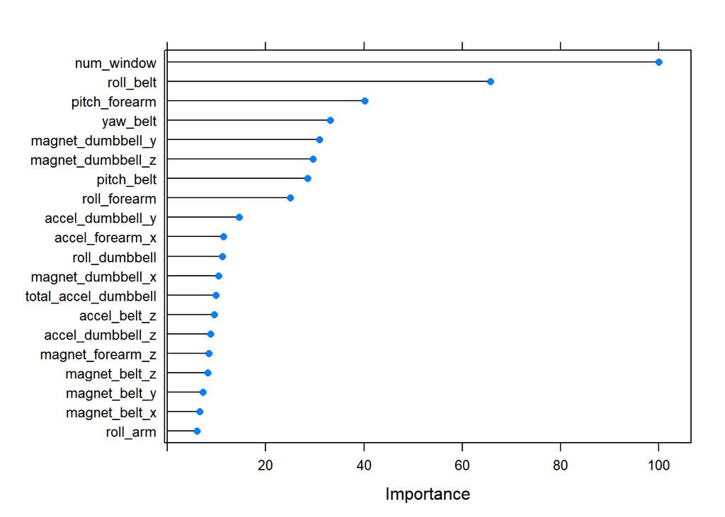

```r
plot(varImp(rf.model), top = 20)
```

## Evaluating the Validation data

As a last step, I will check the performance of this model on the validation data.

```r
filled.validation.data <- predict(fill.data, validation.data)
validation.pred <- predict(rf.model, filled.validation.data)
confusionMatrix(validation.pred, factor(filled.validation.data$classe))
```

```
## Confusion Matrix and Statistics
##
##           Reference
## Prediction    A    B    C    D    E
##          A 1674    0    0    0    0
##          B    0 1138    1    0    2
##          C    0    0 1025    5    0
##          D    0    1    0  958    0
##          E    0    0    0    1 1080
##
## Overall Statistics
##
##                Accuracy : 0.9983
##                  95% CI : (0.9969, 0.9992)
##     No Information Rate : 0.2845
##     P-Value [Acc > NIR] : < 2.2e-16
##
##                   Kappa : 0.9979
##
##  Mcnemar's Test P-Value : NA
##
## Statistics by Class:
##
##                      Class: A Class: B Class: C Class: D Class: E
## Sensitivity            1.0000   0.9991   0.9990   0.9938   0.9982
## Specificity            1.0000   0.9994   0.9990   0.9998   0.9998
## Pos Pred Value         1.0000   0.9974   0.9951   0.9990   0.9991
## Neg Pred Value         1.0000   0.9998   0.9998   0.9988   0.9996
## Prevalence             0.2845   0.1935   0.1743   0.1638   0.1839
## Detection Rate         0.2845   0.1934   0.1742   0.1628   0.1835
## Detection Prevalence   0.2845   0.1939   0.1750   0.1630   0.1837
## Balanced Accuracy      1.0000   0.9992   0.9990   0.9968   0.9990
```

## Final test

With these excellent accuracy results, I feel confident to submit this model to the test data.

```r
test.data <- read.csv("https://d396qusza40orc.cloudfront.net/predmachlearn/pml-testing.csv", na.strings = c("", "" , "NA"))
relevant.test.data <- test.data[, -c(1:5)]
relevant.test.data[, -c(1, 155)] <- as.numeric(unlist(relevant.test.data[, -c(1, 155)]))
filled.test.data <- predict(fill.data, relevant.test.data)
test.pred <- predict(rf.model, filled.test.data)
```